# DATA 316 Exam 1

2/23/2021

## Rules for Exam 1

- As always, we will follow the college’s Academic Honesty and Integrity policies.
- Do not discuss the exam with anyone other than Dr. Tanner. If you need clarification, email Dr. Tanner.
- Allowed resources:
  - Your textbook and notes taken
  - Any resources on the course Moodle page including the Math and Probability Model presentations and the Hypothesis Testing tutorials.
  - RStudio Cheatsheets (Help -> Cheatsheets) and R Documentation help files (lower-left corner of RStudio)
- Keep your answers neat and well-formatted.
- When you are finished, double check that you have answered all questions and upload this file to Moodle.
- Do your best work!

# Part 1 - Fitting Models

For each of the following, construct a model for the relationship between x and y. Write a summary of your model, including:

- a scatterplot containing both the data and the model curve;
- one or more plots of the model residuals, along with a written assessment of these plots;
- reasons for your choice of model;
- your model equation, including the fitted parameter values;
- interpretation of all model parameters in the context of the given variables;
- a summary paragraph assessing the model and what it tells you about the relationship between x and y.

## Problem 1A - Fargo Average Air Temperatures

Use the data in fargo_temp.csv to model the average temperature (TAVG) in the city of Fargo, ND by day.

### Answer

## Problem 1B - Education Spending and Math Scores

USe the data in OECD_raw.csv. The file contains data from the OECD on per-pupil education speding (in US Dollars) and performance on the Math PISA exam for various countries for various years. Use the data to model 2015 PISA scores (where SUBJECT=TOT) (y) using 2013 education spending (x). All data manipulations should be done in R and included in your notebook.

If you are having trouble manipulating the data, you can use OECD_clean.csv for a minor deduction.

### Answer

# Part 2 - Choosing Models

For each of the following scenarios, discuss which type of model you would use to model the relationship between x and y. In your discussion, give the model equation (e.g. y=a+bx)(no numbers needed), give reasons for your choice, and interpret what the parameters would mean in the context of the given variables. Scatterplots have been provided for your convenience.

## Problem 2A - Internet Adoption

x is date; y is the proportion of population penetration (i.e. percent adoption) for Internet in the United States.

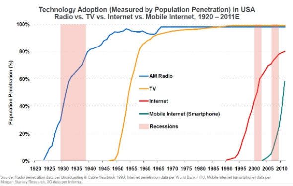

### Answer

## Problem 2B - Mercury in Tuna

x is the time since consumption of a can of tuna (days), y is the amount of methyl mercury in the body (micrograms)

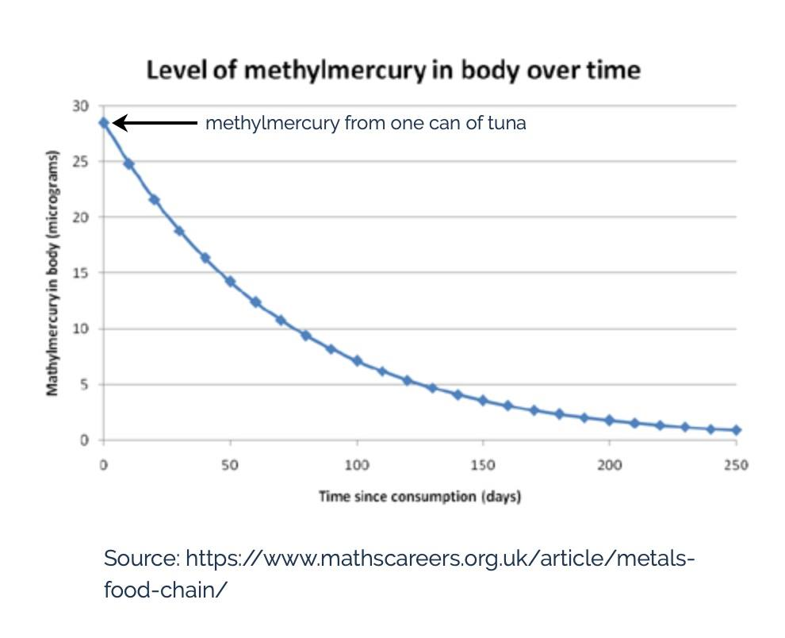

# Part 3 - Probability Distributions

For each of the following variables, determine the probability distribution that best models it. Give one or more reasons for your choice.

## Problem 3A

The number of students that visit the Coffee Stop between 8-9am on Friday morning.

### Answer

## Problem 3B

Today’s high temperature in degress.

### Answer

## Problem 3C

The number of correct answers (out of 10) on a multiple choice quiz.

### Answer

## Problem 3D

The amount of debt each Concordia student will have upon graduation.

### Answer

# Problem 4 - What’s wrong?

The following R output comes from a model done on a study of radon levels in homes in MN. The radon variable measures radon level (in pCi/L), the floor variable measures floor (0 for basement, 1 for ground level), and the county variable contains MN county (numbered from 1 to 85). From the given information, suggest *at least two things that could be done to improve this model.*

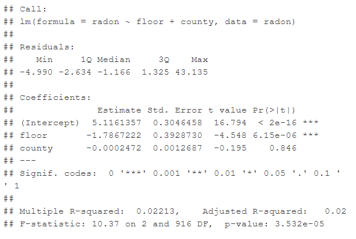

Model Output

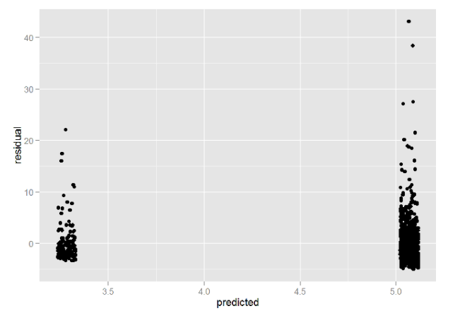

Residuals

### Answer

# Problem 5 - Interpret Coefficients

The following R output comes from a model done on a study of income for adults in the United States. For each adult in the survey, `earn` is annual earnings (in dollars), `height` is their height (inches), `yearbn` is their year of birth, and `ed` is their education level (in years of formal education). Interpret each of the four coefficient estimates in the context of the problem.

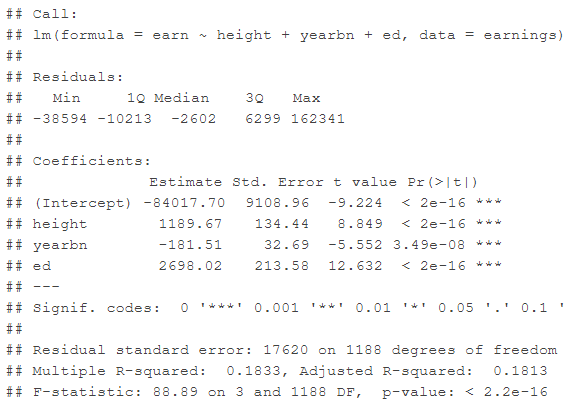

Model Output